# Homework 2: Measuring Model Quality

**Load some handy packages:**

```r
suppressPackageStartupMessages(library(dplyr))
suppressPackageStartupMessages(library(ggplot2))
```

# Review + Residual Analysis

```r
#load the fivethirtyeight library
suppressPackageStartupMessages(library(fivethirtyeight))

#load data
data(hate_crimes)
```

## Exercise 1

```r
hate_crimes1 <- hate_crimes %>% mutate(postHate = hate_crimes_per_100k_splc/10, preHate = avg_hatecrimes_per_100k_fbi/365) %>% mutate(trump50 = (share_vote_trump > 0.5)) %>% mutate(changeHate = postHate - preHate)
```

## Exercise 2

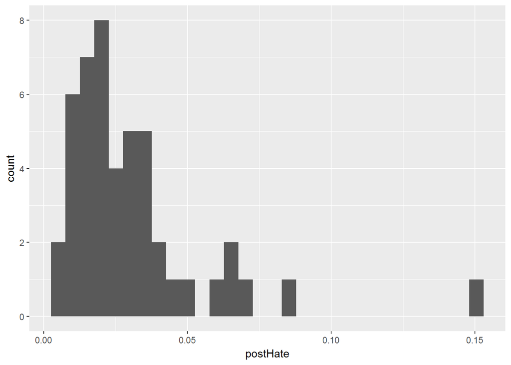

```r
hate_crimes1 %>% ggplot(aes(postHate)) + geom_histogram()
```

```r
hate_crimes1 %>% filter(postHate > 0.12)
```

```
## # A tibble: 1 x 16
##                  state median_house_inc share_unemp_seas share_pop_metro
##                  <chr>            <int>            <dbl>           <dbl>
## 1 District of Columbia            68277            0.067               1
## # ... with 12 more variables: share_pop_hs <dbl>, share_non_citizen <dbl>,
## #   share_white_poverty <dbl>, gini_index <dbl>, share_non_white <dbl>,
## #   share_vote_trump <dbl>, hate_crimes_per_100k_splc <dbl>,
## #   avg_hatecrimes_per_100k_fbi <dbl>, postHate <dbl>, preHate <dbl>,
## #   trump50 <lgl>, changeHate <dbl>
```

This could be because of the number of protests that were organised in the DC area after the presidential election.

```r
hate_sub <- hate_crimes1 %>% filter(postHate< 0.12, )
dim(hate_sub)
```

```
## [1] 46 16
```

```r
mean(hate_sub$postHate, na.rm=TRUE)
```

```
## [1] 0.02776102
```

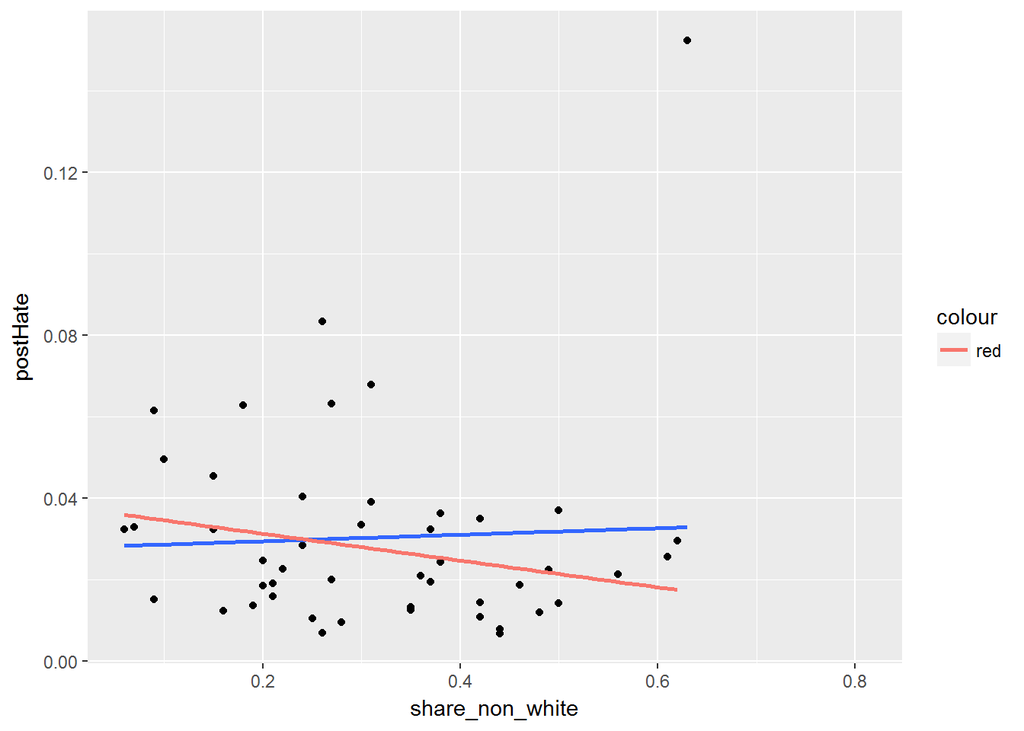

```r
ggplot(hate_crimes1, aes(x=share_non_white, y=postHate)) +
    geom_point() +
    geom_smooth(method="lm",se=FALSE) +
    geom_smooth(data=hate_sub, aes(x=share_non_white, y=postHate, color="red"), method="lm", se=FALSE)
```

## Exercise 3

```r
mod1 <- lm(postHate ~ preHate*trump50, hate_sub)
summary(mod1)
```

```
##
## Call:
## lm(formula = postHate ~ preHate * trump50, data = hate_sub)
##
## Residuals:
##       Min        1Q    Median        3Q       Max
## -0.041779 -0.007955 -0.001900  0.006064  0.041668
##
## Coefficients:
##                      Estimate Std. Error t value Pr(>|t|)
## (Intercept)          0.014970   0.007117   2.104  0.04144 *
## preHate              2.864926   0.964621   2.970  0.00491 **
## trump50TRUE         -0.001260   0.010024  -0.126  0.90057
## preHate:trump50TRUE -1.556091   1.577140  -0.987  0.32946
## ---
## Signif. codes:  0 '***' 0.001 '**' 0.01 '*' 0.05 '.' 0.1 ' ' 1
##
## Residual standard error: 0.01522 on 42 degrees of freedom
## Multiple R-squared:  0.3153, Adjusted R-squared:  0.2664
## F-statistic: 6.448 on 3 and 42 DF,  p-value: 0.001086
```

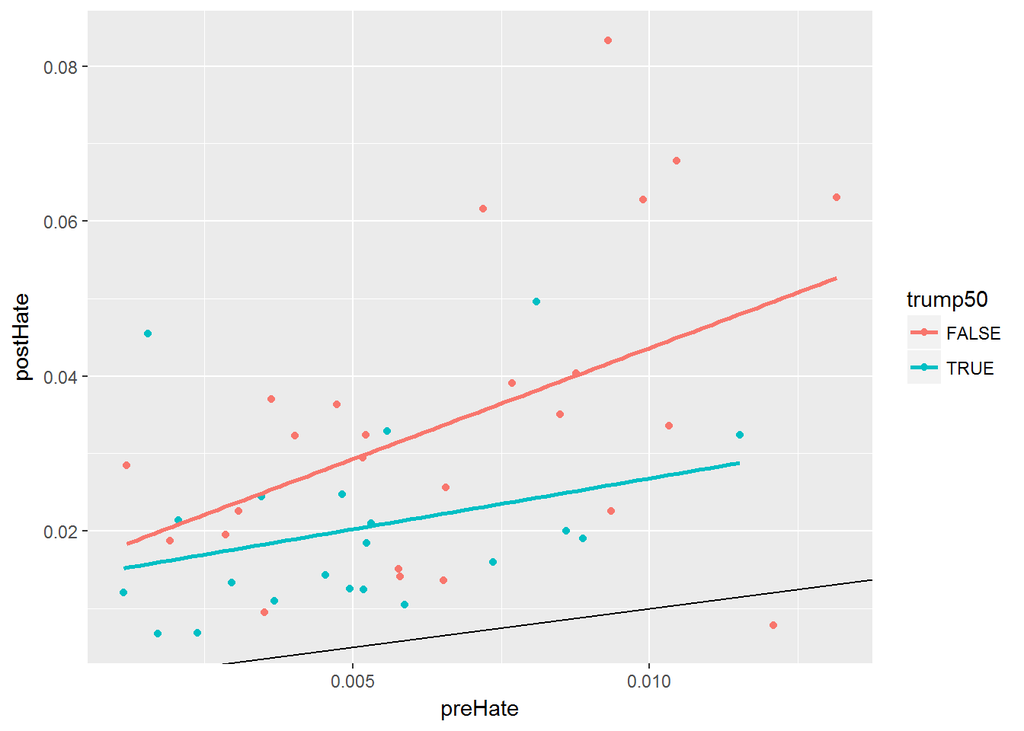

```r
hate_sub %>% ggplot(aes(y = postHate, x = preHate, color = trump50)) + geom_point() + geom_smooth(method = 'lm', se = FALSE) + geom_abline(intercept = 0, slope  = 1)
```

Line with slope 1 and intercept zero represent states where hate crime didn’t change after the election. It is a reference. Points above this line represent states where hate crime increased after election and points below this line represent states where hate crime decreased after the election.

We would expect postHate to correlated preHate (depending on hate crimes in each state) and we want to see how hate crime changed where Trump won. It could have influenced the hate crime rate.

3c. postHate = 0.014970 + 2.864926 preHate + -0.001260 trump50TRUE + -1.556091 (preHate* trump50TRUE)

3d. preHate* trump50TRUE = it quantifies how trump’s win in a state affected the change in postHate crime in that state

## Exercise 4

Assumption1 : Residuals are normally distributed

```r
mod1Results <- data.frame(observed = hate_sub$postHate, predicted = mod1$fitted.values, residual = mod1$residuals)
```

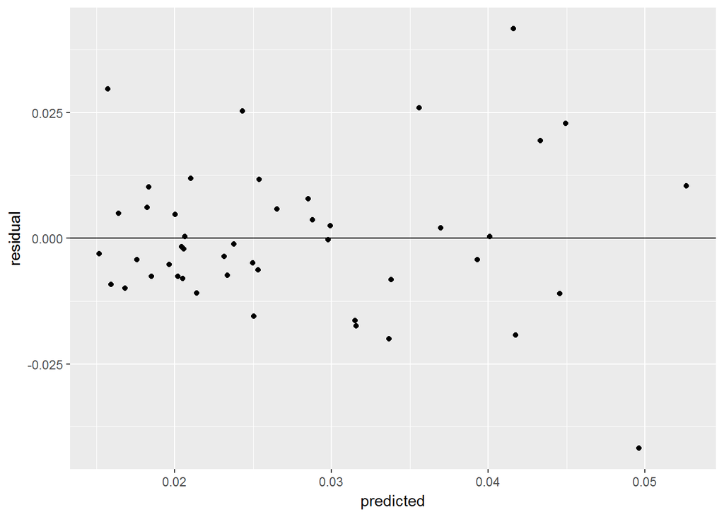

```r
ggplot(mod1Results, aes(y=residual, x=predicted)) +
    geom_point() +
    geom_hline(yintercept=0)
```

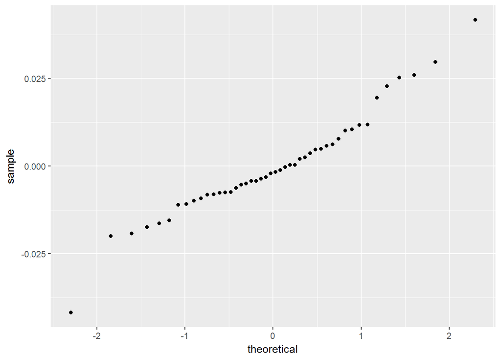

```r
ggplot(mod1Results, aes(sample=residual)) +
    geom_qq()
```

# $R^2$

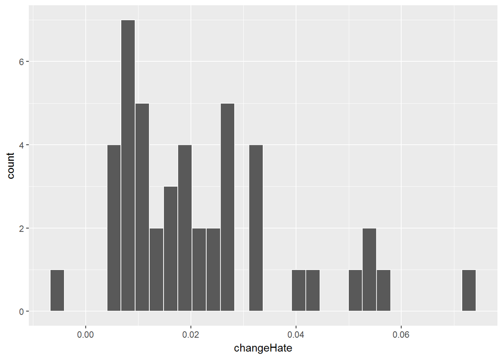

```r
ggplot(hate_sub, aes(x=changeHate)) +
    geom_histogram(color="white")
```

## Exercise 5

```r
library(mosaic)
mod20 <-  lm(changeHate ~ share_non_white, hate_sub)
rsquared(mod20)
```

```
## [1] 0.06160705
```

```r
mod21 <-  lm(changeHate ~ median_house_inc, hate_sub)
rsquared(mod21)
```

```
## [1] 0.06938072
```

```r
mod22 <-  lm(changeHate ~ share_non_white + median_house_inc, hate_sub)
rsquared(mod22)
```

```
## [1] 0.1233249
```

```r
mod23 <-  lm(changeHate ~ share_vote_trump, hate_sub)
rsquared(mod23)
```

```
## [1] 0.1644774
```

```r
mod24 <- lm(changeHate ~ trump50, hate_sub)
rsquared(mod24)
```

```
## [1] 0.1370963
```

```r
mod25 <- lm(changeHate ~ share_vote_trump + trump50, hate_sub)
rsquared(mod25)
```

```
## [1] 0.1675282
```

[output not shown]

## Exercise 6

6a. $R^2$ doesn’t change or increases. Never decreases. 6b. Notice that the model 3 R2R2 is nearly the sum of the R2R2 from models 1 & 2. - Because the predictors are not correlated However, the model 6 R2R2 is very similar to that of models 4 & 5 even though it contains the predictors from both. - Because trump50 is dependent on share_vote_trump. So, adding this redundant predictor doesn’t increase the $R^2$

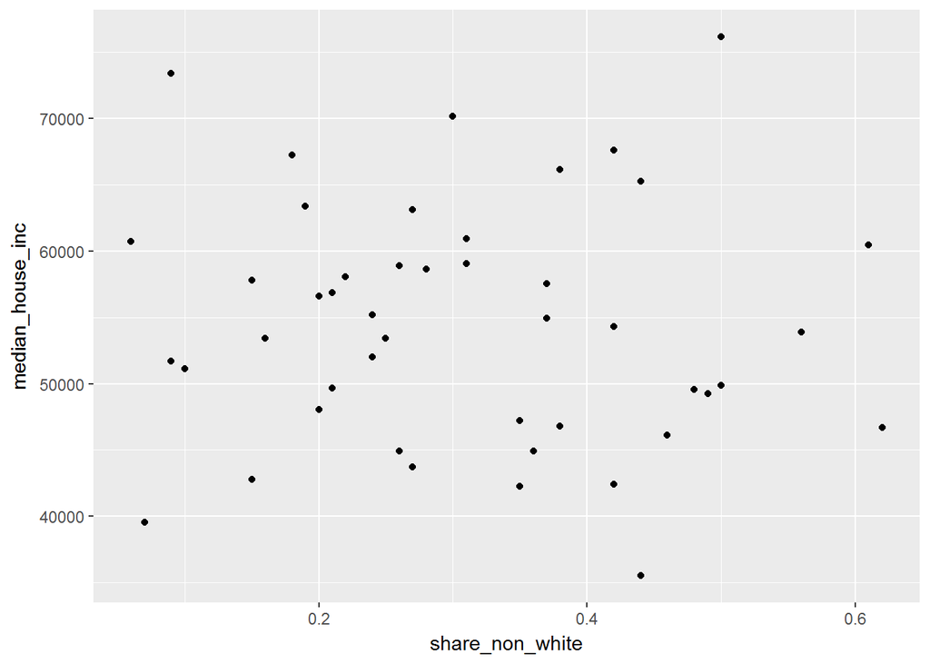

```r
hate_sub %>% ggplot(aes(y = median_house_inc, x = share_non_white)) + geom_point()
```

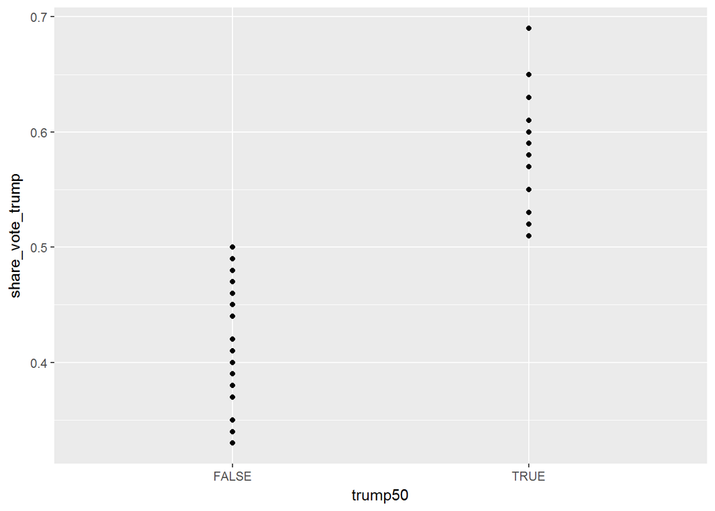

```r
hate_sub %>% ggplot(aes(y = share_vote_trump, x = trump50)) + geom_point()
```

## Exercise 7

# Cross Validation

```r
#Load the data:
suppressPackageStartupMessages(library(DAAG))
data(socsupport)

#get the codebook
?socsupport
```

```
## starting httpd help server ...
```

```
##  done
```

```r
BDImod <- lm(BDI ~ psisat, data=socsupport)
summary(BDImod)
```

```
##
## Call:
## lm(formula = BDI ~ psisat, data = socsupport)
##
## Residuals:
##     Min      1Q  Median      3Q     Max
## -14.064  -5.899  -0.568   3.599  38.766
##
## Coefficients:
##             Estimate Std. Error t value Pr(>|t|)
## (Intercept)  33.0605     4.6410   7.124 2.19e-10 ***
## psisat       -1.8328     0.3745  -4.894 4.14e-06 ***
## ---
## Signif. codes:  0 '***' 0.001 '**' 0.01 '*' 0.05 '.' 0.1 ' ' 1
##
## Residual standard error: 8.567 on 93 degrees of freedom
## Multiple R-squared:  0.2048, Adjusted R-squared:  0.1963
## F-statistic: 23.95 on 1 and 93 DF,  p-value: 4.137e-06
```

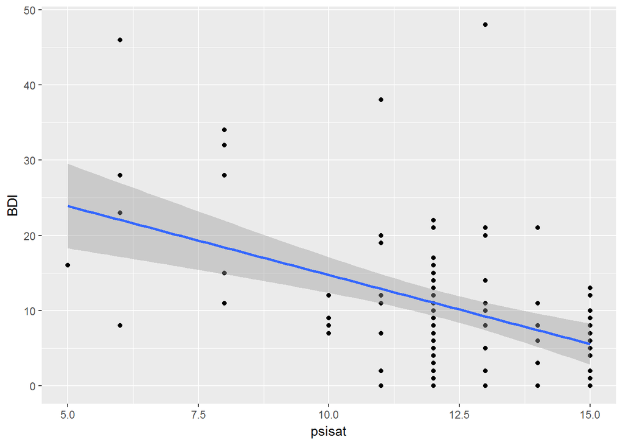

```r
ggplot(socsupport, aes(x=psisat, y=BDI)) +
    geom_point() +
    geom_smooth(method="lm")
```

```r
mean(BDImod$residuals^2)
```

```
## [1] 71.8476
```

```r
## [1] 71.85
sqrt(mean(BDImod$residuals^2))
```

```
## [1] 8.476296
```

```r
## [1] 8.476
dim(socsupport)
```

```
## [1] 95 20
```

## Exercise 8

```r
data_train <- socsupport[-1,]
data_test <- socsupport[1,]

train_mod <- lm(BDI ~ psisat, data = data_train)

train_pred <- makeFun(train_mod)
test_predictions <- train_pred(psisat = data_test$psisat)
mean((test_predictions - data_test$BDI)^2)
```

```
## [1] 18.3571
```

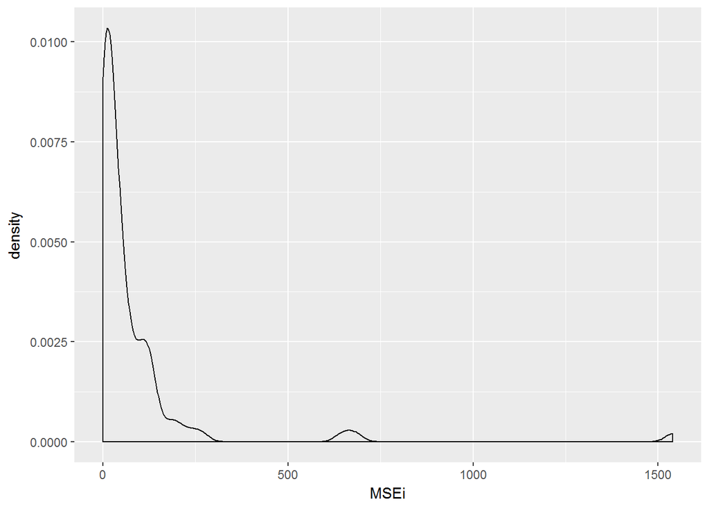

```r
MSEi = rep(0, nrow(socsupport))


for(i in 1: nrow(socsupport)){

data_train <- socsupport[-i,]
data_test <- socsupport[i,]

train_mod <- lm(BDI ~ psisat, data = data_train)
train_pred <- makeFun(train_mod)
test_predictions <- train_pred(psisat = data_test$psisat)
MSEi[i] <- mean((test_predictions - data_test$BDI)^2)

}

MSEdata <- data.frame(MSEi)

MSEdata %>% ggplot(aes(MSEi)) + geom_density()
```

```r
cv <- mean(MSEi)
cv
```

```
## [1] 75.70166
```

```r
mean(BDImod$residuals^2)
```

```
## [1] 71.8476
```

## Exercise 9

```r
suppressPackageStartupMessages(library(boot))

#fit the model using the glm() not lm() function
mod <- glm(BDI ~ psisat, data=socsupport, family="gaussian")

#perform n-fold cross validation using cv.glm()
cv.err <- cv.glm(socsupport, mod, K=95)

#report the CV error (value on the left)
cv.err$delta
```

```
## [1] 75.70166 75.68084
```

## Exercise 10

```r
set.seed(50)

cv10.err <- cv.glm(socsupport, mod, K=10)
cv10.err$delta
```

```
## [1] 76.97777 76.69912
```

```r
cv2.err <- cv.glm(socsupport, mod, K=2)
cv2.err$delta
```

```
## [1] 83.53292 79.61649
```

10d. 2-fold CV

# Overfitting

## Exercise 11

```r
mod <- lm(changeHate ~ median_house_inc, data=hate_sub)
summary(mod)
```

```
##
## Call:
## lm(formula = changeHate ~ median_house_inc, data = hate_sub)
##
## Residuals:
##       Min        1Q    Median        3Q       Max
## -0.031235 -0.009206 -0.003137  0.005105  0.050045
##
## Coefficients:
##                    Estimate Std. Error t value Pr(>|t|)
## (Intercept)      -4.127e-03  1.454e-02  -0.284   0.7779
## median_house_inc  4.767e-07  2.632e-07   1.811   0.0769 .
## ---
## Signif. codes:  0 '***' 0.001 '**' 0.01 '*' 0.05 '.' 0.1 ' ' 1
##
## Residual standard error: 0.01613 on 44 degrees of freedom
## Multiple R-squared:  0.06938,    Adjusted R-squared:  0.04823
## F-statistic:  3.28 on 1 and 44 DF,  p-value: 0.07694
```

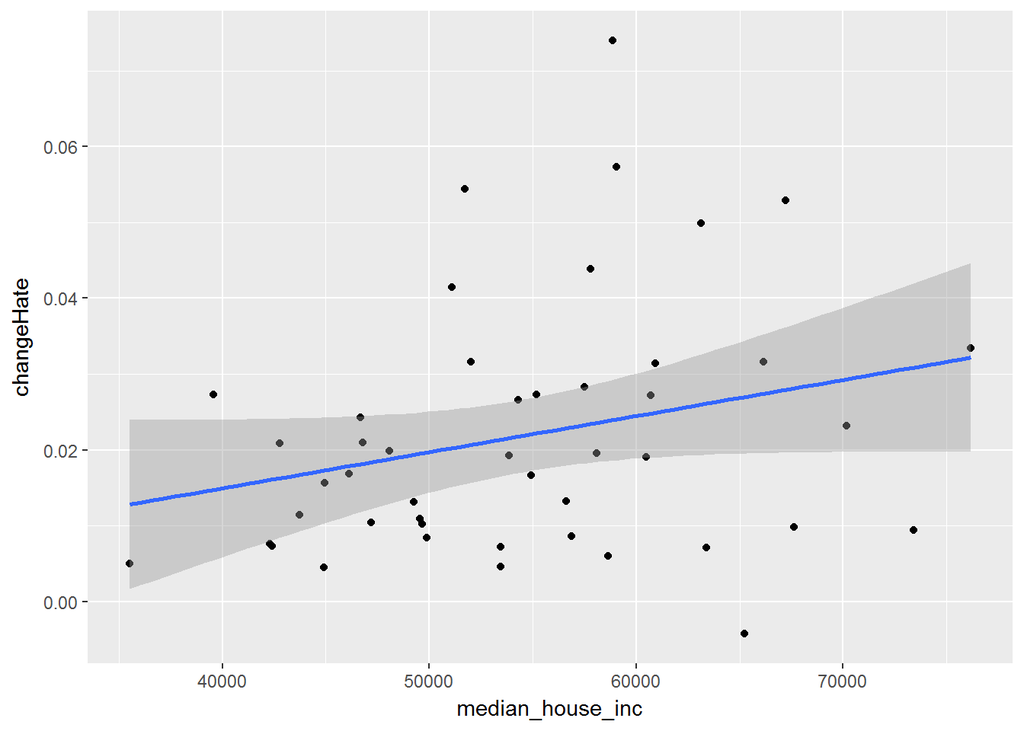

```r
ggplot(hate_sub, aes(x=median_house_inc, y=changeHate)) +
    geom_point() +
    geom_smooth(method="lm")
```

```r
mod <- glm(changeHate ~ median_house_inc, data=hate_sub, family="gaussian")
set.seed(2000)
cv10.err <- cv.glm(hate_sub, mod, K=10)
cv10.err$delta
```

```
## [1] 0.0002781563 0.0002764033
```

```r
polymod <- lm(changeHate ~ poly(median_house_inc, degree=3), hate_sub)
rsquared(polymod)
```

```
## [1] 0.1011816
```

```r
mod <- glm(changeHate ~ poly(median_house_inc, degree=3), data=hate_sub, family="gaussian")
set.seed(2000)
cv10.err <- cv.glm(hate_sub, mod, K=10)
cv10.err$delta
```

```
## [1] 0.0003094298 0.0003048410
```

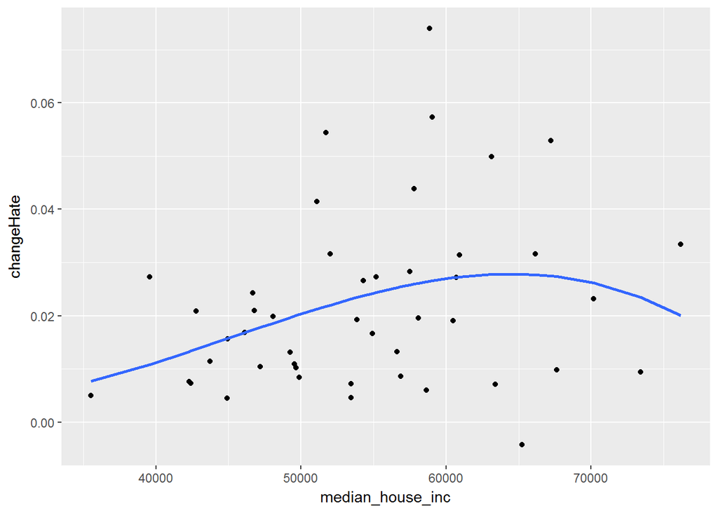

```r
#for each state's median_house_inc, store the model predicted changeHate
polymodresults <- data.frame(median_house_inc=hate_sub$median_house_inc, prediction=polymod$fitted.values)

#order the cases by median_house_inc
polymodresults <- arrange(polymodresults, median_house_inc)

#plot model and cases
ggplot(hate_sub, aes(x=median_house_inc, y=changeHate)) +
    geom_point() +
    geom_smooth(data=polymodresults, aes(x=median_house_inc, y=prediction), stat="identity")
```

## Exercise 12

```r
polymod2 <- lm(changeHate ~ poly(median_house_inc, degree=16), hate_sub)
rsquared(polymod2)
```

```
## [1] 0.2920513
```

```r
mod <- glm(changeHate ~ poly(median_house_inc, degree=16), data=hate_sub, family="gaussian")
set.seed(2000)
cv10.err <- cv.glm(hate_sub, mod, K=10)
cv10.err$delta
```

```
## [1] 246272.2 219498.3
```

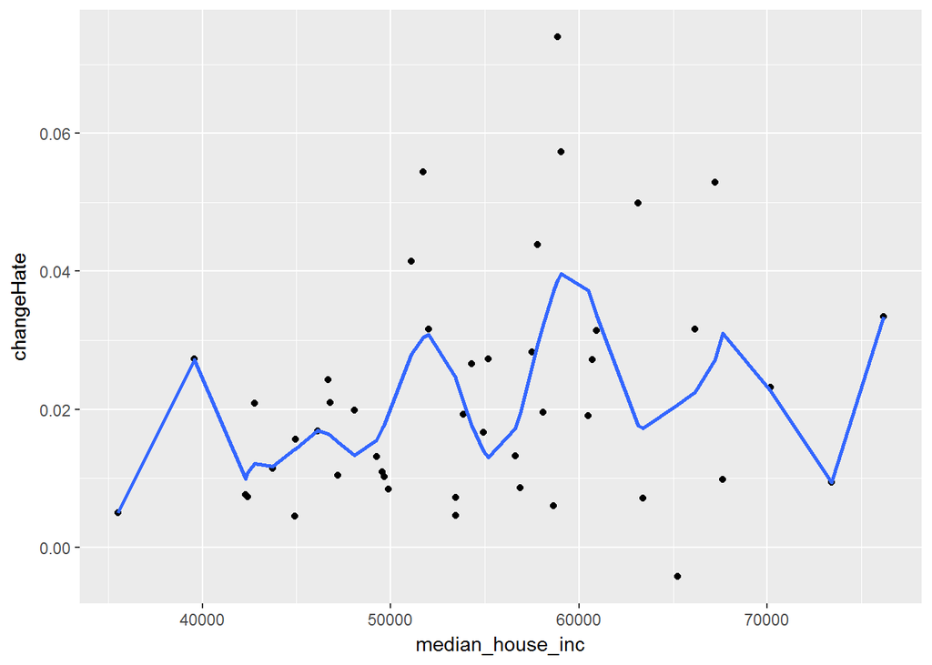

```r
#for each state's median_house_inc, store the model predicted changeHate
polymodresults2 <- data.frame(median_house_inc=hate_sub$median_house_inc, prediction=polymod2$fitted.values)

#order the cases by median_house_inc
polymodresults2 <- arrange(polymodresults2, median_house_inc)

#plot model and cases
ggplot(hate_sub, aes(x=median_house_inc, y=changeHate)) +
    geom_point() +
    geom_smooth(data=polymodresults2, aes(x=median_house_inc, y=prediction), stat="identity")
```

## Exercise 13

| Model | $R^2$ | CV error |
| --- | --- | --- |
| 1st order poly | 0.06938 | 0.0002781563 |
| 3rd order poly | 0.1011816 | 0.0003094298 |
| 16th order poly | 0.2920513 | 246272.2 |

a and b. Because of overfitting our model is not generic enough for test data. It explains the variability of the training set but not test set as it makes predictions which have large residual error.

## Exercise 14

```r
mod14 <- lm(changeHate ~ gini_index, data=hate_crimes1)
summary(mod14)
```

```
##
## Call:
## lm(formula = changeHate ~ gini_index, data = hate_crimes1)
##
## Residuals:
##       Min        1Q    Median        3Q       Max
## -0.030785 -0.012708 -0.006212  0.006806  0.075318
##
## Coefficients:
##             Estimate Std. Error t value Pr(>|t|)
## (Intercept) -0.11253    0.06911  -1.628   0.1105
## gini_index   0.29968    0.15155   1.977   0.0541 .
## ---
## Signif. codes:  0 '***' 0.001 '**' 0.01 '*' 0.05 '.' 0.1 ' ' 1
##
## Residual standard error: 0.02128 on 45 degrees of freedom
##   (4 observations deleted due to missingness)
## Multiple R-squared:  0.07995,    Adjusted R-squared:  0.0595
## F-statistic:  3.91 on 1 and 45 DF,  p-value: 0.05414
```

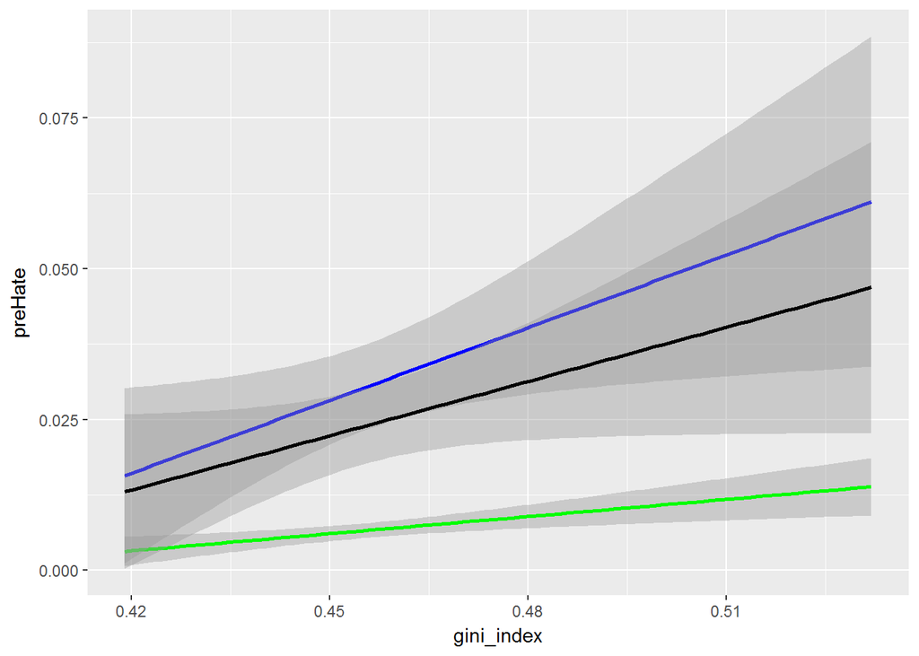

```r
ggplot(hate_crimes1, aes(x = gini_index, y = preHate)) +
geom_smooth(method ='lm', color = 'green') + geom_smooth(data = hate_crimes1,aes(x = gini_index, y = postHate), method = 'lm', color= 'blue') + geom_smooth(data = hate_crimes1,aes(x = gini_index, y = changeHate), method = 'lm', color= 'black')
```